# Reproducible Research: Peer Assessment 1

Some basic settings:

```r
    # setting timelocale to English. Im in Finland so I do this just in case
    Sys.setlocale("LC_TIME", "English")
```

```
## [1] "English_United States.1252"
```

```r
    #load ggplot2 for qplot
    library(ggplot2)
```

## Loading and preprocessing the data

Loading data form file activity.csv, first we unzip file activity.zip, if needed

- Loading data
- File activity.zip is supposed to be found from working directory, if not please uplod it from:  
  https://d396qusza40orc.cloudfront.net/repdata%2Fdata%2Factivity.zip
- Also I change txt date strig to Date type

```r
    if(!file.exists("activity.csv")) {
        unzip("activity.zip")
        }

    actdata <- read.csv("activity.csv", stringsAsFactors=FALSE)
    actdata$date <- as.Date(actdata$date, "%Y-%m-%d")
```

#### Basic summary of activity data:

```r
    summary(actdata)
```

```
##      steps             date               interval
##  Min.   :  0.00   Min.   :2012-10-01   Min.   :   0.0
##  1st Qu.:  0.00   1st Qu.:2012-10-16   1st Qu.: 588.8
##  Median :  0.00   Median :2012-10-31   Median :1177.5
##  Mean   : 37.38   Mean   :2012-10-31   Mean   :1177.5
##  3rd Qu.: 12.00   3rd Qu.:2012-11-15   3rd Qu.:1766.2
##  Max.   :806.00   Max.   :2012-11-30   Max.   :2355.0
##  NA's   :2304
```

```r
    totalcases <- nrow(actdata)
    ok <- sum(complete.cases(actdata))
    notok <- sum(!complete.cases(actdata))
```

- Number of total cases is: 17568 and number of cases with missing data is 2304.
- Missing percentage is 13.1 %

## What is mean total number of steps taken per day?

Calculation of mean values for steps taken per day, removing missing values

```r
    daysteps <- aggregate(actdata$steps, by=list(date=actdata$date), FUN=sum)
    colnames(daysteps) <- c("Date", "steps")
    avg <- mean(daysteps$steps, na.rm=TRUE)
    med <- median(daysteps$steps, na.rm=TRUE)
    total <- sum(daysteps$steps, na.rm=TRUE)
    #set names to daystep data
```

- Mean value of total number of steps taken per day is 10766.19
- Median value ot total number of steps taken per day is 10765

#### From histogram we get more detail information about distribution of steps/day

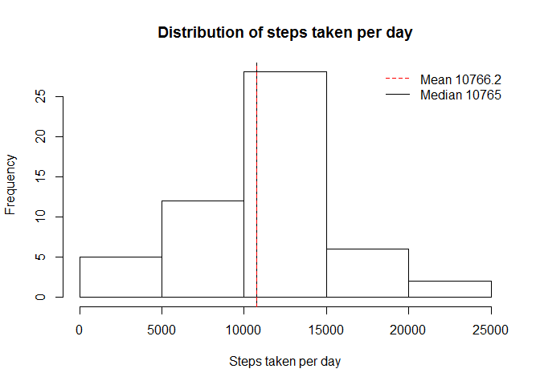

```r
    hist(daysteps$steps,
        breaks=5,
        xlab="Steps taken per day",
        main="Distribution of steps taken per day"
        )

        abline(v = med, col = "black", lwd = 1, lty=1)
        abline(v = avg, col = "red", lwd = 1, lty=2)

        legend(
            "topright",
            bty="n",
            col=c("red", "black"),
            legend=c(paste("Mean", round(avg,1)), paste("Median", round(med,1))),
            lty=c(2,1)
            )
```

## What is the average daily activity pattern?

```r
    intersteps <- aggregate(actdata$steps,
                            by=list(actdata$interval),
                            FUN=mean,
                            na.rm=TRUE
                            )
    colnames(intersteps) <- c("interval", "steps")
    #Find row where is maximum value
    ismax <- intersteps$steps==max(intersteps$steps)
    #Extract maximum values
    maxinterval <- intersteps[ismax,"interval"]
    maxval <- intersteps[ismax,"steps"]
```

- Interval: 835 has maximum steps: 206.2 from all intervals.
- We can see this also from graph below code, where average steps are plotted against intervals

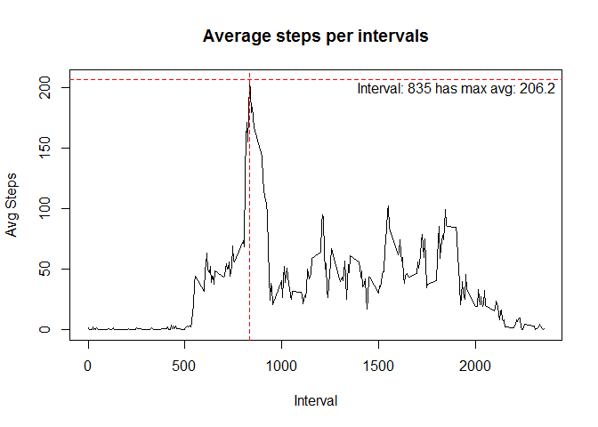

```r
    plot(intersteps$steps ~ intersteps$interval,
        type="l",
        xlab="Interval",
        ylab="Avg Steps",
        main="Average steps per intervals"
        )

        #lines for locate interval with maximum value
    abline(v = maxinterval, h=maxval, col = "red", lwd = 1, lty=2)

    legend("topright",
            bty="n",
            legend=paste("Interval:", maxinterval, "has max avg:", round(maxval,1)
                         )
            )
```

## Imputing missing values

```r
    imputedata <- actdata
    #impute missing values with precalculted avg values, from step: What is the average daily activity pattern??
    imputedata$steps <- ifelse(!is.na(imputedata$steps), imputedata$steps, intersteps[,2])
```

#### Summary of the imputed data

```r
    summary(imputedata)
```

```
##      steps             date               interval
##  Min.   :  0.00   Min.   :2012-10-01   Min.   :   0.0
##  1st Qu.:  0.00   1st Qu.:2012-10-16   1st Qu.: 588.8
##  Median :  0.00   Median :2012-10-31   Median :1177.5
##  Mean   : 37.38   Mean   :2012-10-31   Mean   :1177.5
##  3rd Qu.: 27.00   3rd Qu.:2012-11-15   3rd Qu.:1766.2
##  Max.   :806.00   Max.   :2012-11-30   Max.   :2355.0
```

I calculate:

- mean,
- median and
- total values

of steps per day again to compare result with original and imputed data

```r
    daystepsImp <- aggregate(imputedata$steps, by=list(imputedata$date), FUN=sum)
    colnames(daystepsImp) <- c("date", "steps")
    avgImp <- mean(daystepsImp$steps, na.rm=TRUE)
    medImp <- median(daystepsImp$steps, na.rm=TRUE)
    totalImp <- sum(daystepsImp$steps, na.rm=TRUE)
```

Histogram from data where missing values are replaced.

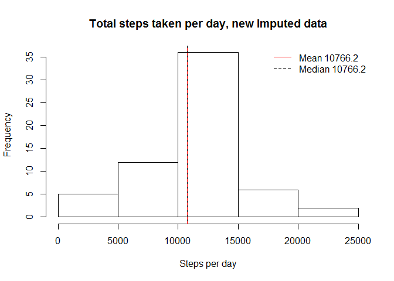

```r
    hist(daystepsImp$steps,
        xlab="Steps per day",
        main="Total steps taken per day, new Imputed data"
        )

    #put lines for mean and median values
    abline(v = medImp, col = "black", lwd = 1, lty=1)
    abline(v = avgImp, col = "red", lwd = 1, lty=2)

    legend("topright",
        bty="n",
        col=c("red", "black"),
        legend=c(paste("Mean", round(avgImp,1)),
                    paste("Median", round(medImp,1))
                 ),
       lty=c(1,2)
       )
```

## Are there differences in activity patterns between weekdays and weekends?

- Now I investigate differences with weekdays and weekends. First I have to find weekpart, based on weekdays.
- After that I can make graphs to investigation.

```r
    imputedata$weekpart <- ifelse(weekdays(imputedata$date) %in% c("Monday", "Tuesday", "Wednesday", "Thursday", "Friday"),
                                "Weekday",
                                "Weekend"
                                )

    ImputedataMean <- aggregate(imputedata$steps,
                                by=list(imputedata$interval, imputedata$weekpart),
                                FUN=mean
                                )
    colnames(ImputedataMean) <- c("interval", "weekpart", "steps")
```

On following graphs I investigate, that is there differece between weekdays and weekend days activity. I used Imputed data for this investigation.

- on x-axis there is 5-minute intervals
- on y-axis is average number of steps on interval

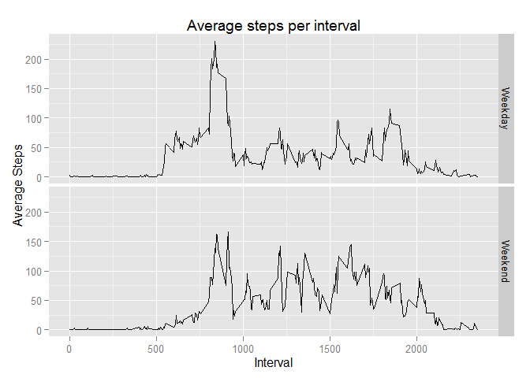

```r
    qplot(interval, steps,
        geom="line",
        data=ImputedataMean,
        facets = weekpart~.,
        main="Average steps per interval",
        xlab="Interval",
        ylab="Average Steps"
        )
```

- Some variation can be noticed.
- Anyway I put both to same plot to indentify that variation better.
- Below looks like that on earlier (<1000) intrevals there is more steps on weekdays and after intervals 1000 there is more steps on weekend days.

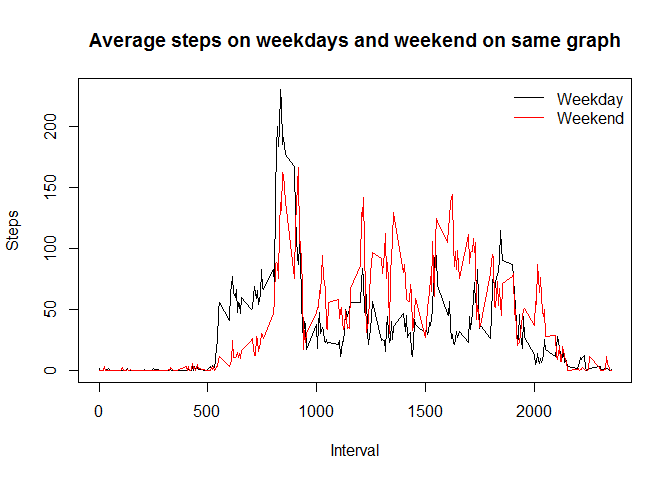

```r
#create vector to separate data for plot
    weekday <- ImputedataMean$weekpart=="Weekday"

    plot(ImputedataMean[weekday,"steps"] ~ ImputedataMean[weekday,"interval"],
        type="l", col="black",
        main="Average steps on weekdays and weekend on same graph",
        xlab="Interval",
        ylab="Steps"
        )

    lines(ImputedataMean[!weekday,"steps"] ~ ImputedataMean[!weekday,"interval"],
        type="l", col="red"
        )

    legend(
        "topright",
        bty="n",
        col=c("black", "red"),
        legend=c("Weekday", "Weekend"),
        lty=c(1,1)
        )
```